# Research Methods in Political Science I

Assignment 3

Sohei Shigemura

October 28, 2015

# I. Calculation of Factorial

The factorial of a non-negative integer $n$ is denoted $n!$, and $n! = n(n - 1)(n - 2)\cdots 1,$ where $0!=1$.

To calculate factorials, I cretate an R function below other than using the built-in function.

```r
r.fct <- function(n){ ## function to calculate factorials
  if(n == 0){ ## if n is 0, the formula of n = 1 is returned
    return(n = 1)
  }
  else{ ## if n is not 0, the formula of n(n-1)(n-2)...1 is returned
    return(n * r.fct(n - 1 : 1))
  }
}
```

We are able to get the outcome by using the function above, for instance, the case of calculating $0!$ is

```r
r.fct(0)
```

```
## [1] 1
```

and $5!$ is

```r
r.fct(5)
```

```
## [1] 120
```

# II. Calculation of Combination

This is a formula which denotes choosing k elements from n ${n \choose k} = \frac{n!}{k!(n-k)!}$

By using the function to calculate factorial above, I create an R function calculating the number of possible combinations that can be obtained by taking a subset of elements from a larger set.

```r
cmbntn <- function(n, k){ ## function to calculate combination
  com <- r.fct(n) / (r.fct(n - k) * r.fct(k))
  return(com)
}
```

Then, we can actually calculate combination, for instance, in the case of ${5 \choose 2}$, the result is as below:

```r
cmbntn(5, 2)
```

```
## [1] 10
```

and in the case of ${20 \choose 18}$, the result is

```r
cmbntn(20, 18)
```

```
## [1] 190
```

# III. Calculation of Probability Mass of Binomial Distribution

The PMF of a random variable $X$ can be written as $f(x) = {n \choose x} p^{x} (1-p)^{(n-x)}~~~~~~~(x=0,1,2,\cdots, n)$ By denoting the binomial distribution as $b(n, p)$, it is possible to say: $X \sim b(n,p)$ where $n$ is the number of independent bernoulli trials, and $p$ is the probability of success for each trial.

By using the function I make at second question, I create a R function to calculate probability mass of binomial distributions as below.

```r
Pmf <- function(x, n, p){ ## function to calculate PMF of binomial distribution
  ## arguments:
  ## x = number of successe for each trial
  ## n = number of bernoulli trials
  ## p = probability of succesful outocome
  binPmf <- r.fct(n) / (r.fct(n - x) * r.fct(x)) * p^x *(1 - p)^(n - x)
  return(binPmf)
}
```

```r
Pmf(2, 2, 0.3)
```

```
## [1] 0.09
```

Moreover, in the case of $x = 2$, $n = 2$, and $p = 0.6$, we get the result as below.

```r
Pmf(2, 2, 0.6)
```

```
## [1] 0.36
```

# IV. Displaying Graphically the PMF of Binomial Distribution

## The case of p = 0.3

### n = 2

To display graphically the PMF of binomial distributions for $n = 2$, $5$, $10$, and $50$, I write commands by using the function I create at third question.

First of all, we have to load the packages we will use.

```r
library(ggplot2)
library(gridExtra)
```

Then, we determine the number of trials $(n)$ and probability of succesful outcome $(p)$,

```r
n <- 2  ## setting the number of trials
p <- 0.3  ## setting the probability of succesful outcome
```

in addition, make a variable to save the results got from the simulations.

```r
## making variables to save the results from the simulations
bin01 <- c(Pmf(0, n, p), rep(NA, n))  ## PMF of binomial distribution
trl <- 0:2  ## the number of trials
```

After that, we need preparing to use for loop to run a simulation.

```r
for(i in 1:n){ ## loop for the simulation, i = 1, 2, ..., trials
   b <- Pmf(i, n, p)  ## assigning the results of calculating PMF to b
   bin01[i + 1] <- b  ## storing b(results) in bin01
}
```

Finally, we use ggplot to visualize the results.

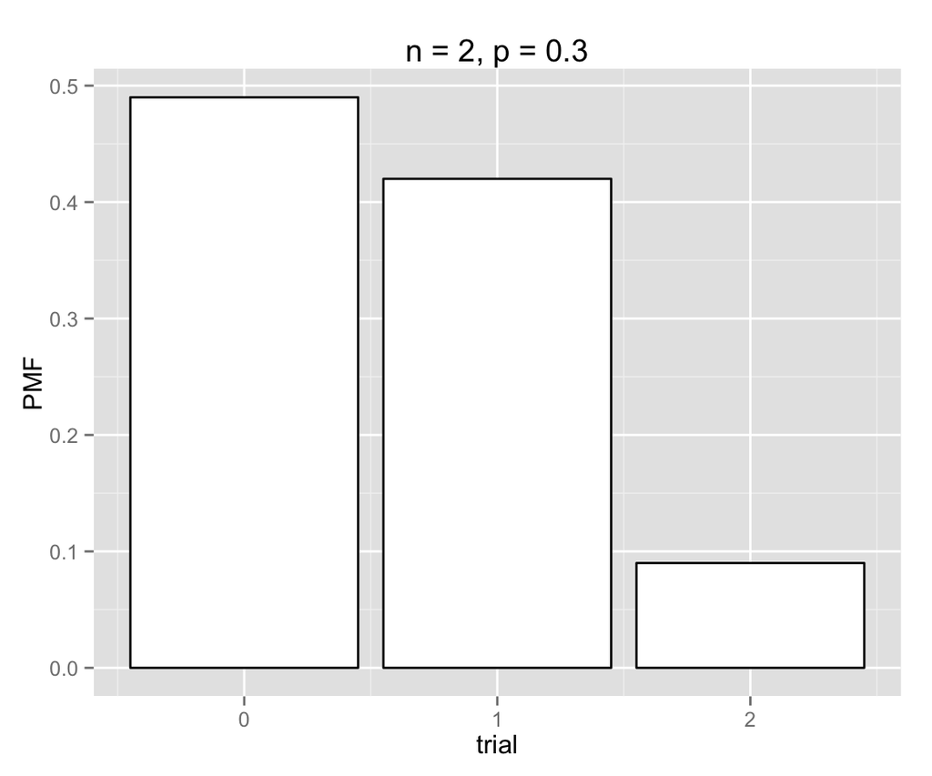

```r
## making a data frame to use ggplot
deta <- data.frame(bin01, trl)
## making a plot
ss50 <- ggplot(deta, aes(x = trl, y = bin01)) +
geom_bar(stat = "identity", aes(), colour = "black", fill = "white") +
ylab("PMF") +
xlab("trial") +
ggtitle("n = 2, p = 0.3")
print(ss50)
```

### n = 5

We can use same commands written above to visualize the results, however need to change the number of trials and the probability of succesful outcome so that we get another results.

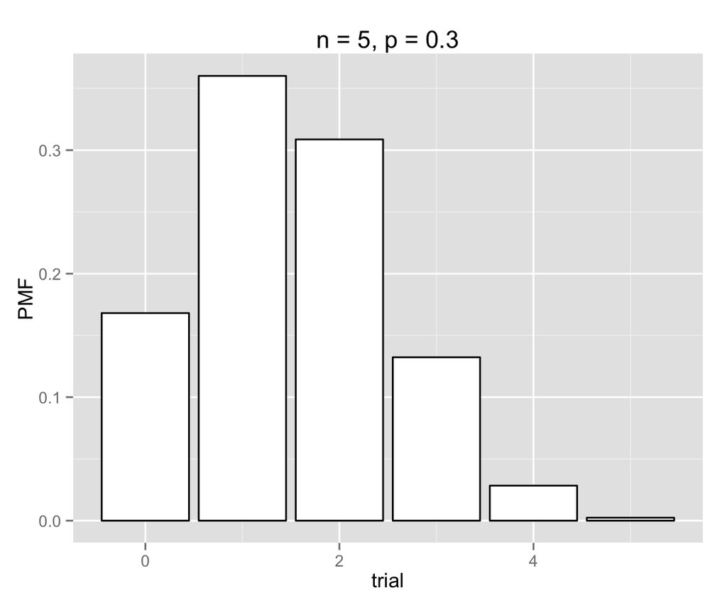

```r
n <- 5
p <- 0.3
bin01 <- c(Pmf(0, n, p), rep(NA, n))
trl <- 0:5
for(i in 1:n){
   b <- Pmf(i, n, p)
   bin01[i + 1] <- b
}
deta <- data.frame(bin01, trl)
ss55 <- ggplot(deta, aes(x = trl, y = bin01)) +
geom_bar(stat = "identity", aes(), colour = "black", fill = "white") +
ylab("PMF") +
xlab("trial") +
ggtitle("n = 5, p = 0.3")
print(ss55)
```

### n = 10

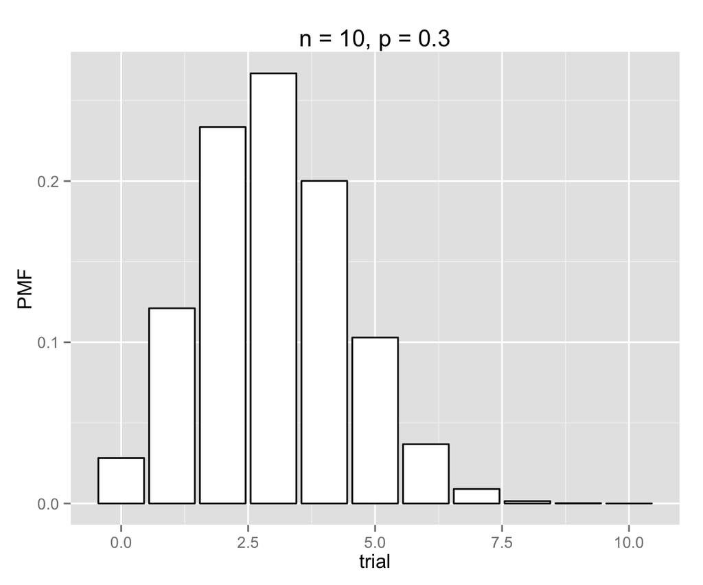

```r
n <- 10
p <- 0.3
bin01 <- c(Pmf(0, n, p), rep(NA, n))
trl <- 0:10
for(i in 1:n){
   b <- Pmf(i, n, p)
   bin01[i + 1] <- b
}
deta <- data.frame(bin01, trl)
ss60 <- ggplot(deta, aes(x = trl, y = bin01)) +
geom_bar(stat = "identity", aes(), colour = "black", fill = "white") +
ylab("PMF") +
xlab("trial") +
ggtitle("n = 10, p = 0.3")
print(ss60)
```